# Chapter 07: Analysis of Function: Sentence Modes

7.5.1 Non-register-tier analysis of intonational phonology

## Raw Data

```r
tot_rows = nrow(m_corpus)
threshold = 8

keep_list <- m_corpus %>%
  mutate(phr_phon = factor(phr_phon, levels = unique(phr_phon))) %>%
  group_by(phr_phon) %>%
  summarise(phon_count = n()) %>%
  filter(phon_count >= 8)
```

### Nuclear Pitch Accent by Speaker

```r
# Create summary table of Pitch Accent by Speaker.
m_corpus %>%
  group_by(speaker, acc_phon) %>%
  summarise(acc_count = n(), .groups = "keep") %>%
  pivot_wider(names_from = acc_phon,
              values_from = acc_count,
              values_fill = 0) %>%
  select("speaker", "H*", "L*H", ">H*")  %>%
  rename_all(list( ~ str_replace_all(., "([\\*\\[\\^\\>])", "\\\\\\1"))) %>%
  adorn_totals(where = "row") %>%
  formattable(
    caption =
      "Distibution by speaker of nuclear pitch accents in M-corpus (raw)",
    list(area(col = 2:4, row = 1:nrow(.) - 1) ~ proportion_bar(color = c(
      rep(brewer.pal(6, "Pastel2")[1], 11),
      rep(brewer.pal(6, "Pastel2")[3], 11),
      rep(brewer.pal(6, "Pastel2")[4], 11)

    ))))
```

Distibution by speaker of nuclear pitch accents in M-corpus (raw)

| speaker | H* | L*H | >H* |
| --- | --- | --- | --- |
| F5 | 0 | 59 | 0 |
| F6 | 0 | 60 | 0 |
| F12 | 0 | 60 | 0 |
| F15 | 0 | 60 | 0 |
| F16 | 0 | 60 | 0 |
| F17 | 0 | 55 | 0 |
| M4 | 0 | 57 | 0 |
| M5 | 0 | 60 | 0 |
| M8 | 2 | 54 | 5 |
| M9 | 0 | 47 | 0 |
| M10 | 0 | 60 | 0 |
| Total | 2 | 632 | 5 |

### Utterance Phonology (most common)

```r
m_corpus %>%
  mutate(phr_phon = factor(phr_phon, levels = unique(phr_phon))) %>%
  filter(phr_phon %in% keep_list$phr_phon) %>%
  group_by(mode, phr_phon) %>%
  summarise(phon_count = n(), .groups = "rowwise") %>%
  arrange(desc(phon_count)) %>%
  mutate(phr_phon = str_replace_all(phr_phon,
                                    "(\\*)", "\\\\\\1")) %>%
  pivot_wider(names_from = mode,
              values_from = phon_count,
              values_fill = 0) %>%
  select(phr_phon, MDC, MWH, MYN, MDQ) %>%
  rowwise(phr_phon) %>%
  mutate(total = sum(c_across())) %>%
  tibble::rowid_to_column("#") %>%
  rename("Phonology" = phr_phon) %>%
  formattable(
    align = "r",
    caption = paste(
      "Utterance level intonational phonology by mode ",
      "for tokens accounting for at least ",
      percent(threshold / tot_rows),
      " of all tokens.",
      sep = ""
    ),
    list(
      area(col = 3:6) ~ proportion_bar(color = c(
        rep(brewer.pal(4, "Pastel2")[3], nrow(.)),
        rep(brewer.pal(4, "Pastel2")[2], nrow(.)),
        rep(brewer.pal(4, "Pastel2")[1], nrow(.)),
        rep(brewer.pal(4, "Pastel2")[4], nrow(.))
      )),
      total = proportion_bar(color = "#aaaaaa")
    )
  )
```

Utterance level intonational phonology by mode for tokens accounting for at least 1.25% of all tokens.

| # | Phonology | MDC | MWH | MYN | MDQ | total |
| --- | --- | --- | --- | --- | --- | --- |
| 1 | % H* L* L*H % | 5 | 53 | 0 | 0 | 58 |
| 2 | % >H* L*H % | 30 | 0 | 38 | 27 | 95 |
| 3 | % L*H % | 32 | 0 | 37 | 28 | 97 |
| 4 | % H* L*H % | 33 | 0 | 11 | 5 | 49 |
| 5 | % L*H L*H % | 25 | 0 | 29 | 24 | 78 |
| 6 | % H* L*!H L*H % | 0 | 21 | 0 | 0 | 21 |
| 7 | % H* L*H L*H % | 0 | 17 | 0 | 0 | 17 |
| 8 | % H* !H* L*H % | 5 | 17 | 0 | 0 | 22 |
| 9 | % L*H L% | 1 | 0 | 12 | 12 | 25 |
| 10 | % >H* L*H L% | 10 | 0 | 8 | 11 | 29 |
| 11 | % H* L*H L% | 6 | 0 | 4 | 10 | 20 |
| 12 | % L*H H% | 0 | 0 | 4 | 9 | 13 |
| 13 | % >H* L*!H L*H % | 0 | 8 | 0 | 0 | 8 |
| 14 | % H* L*H % | 3 | 8 | 1 | 0 | 12 |
| 15 | % L*H L*H L% | 1 | 0 | 1 | 8 | 10 |

### Utterance Phonology (all)

```r
m_corpus %>%
  mutate(phr_phon = factor(phr_phon, levels = unique(phr_phon))) %>%

  group_by(phr_phon) %>%
  summarise(phon_count = n()) %>%
  arrange(desc(phon_count)) %>%
  mutate(phr_phon = str_replace_all(phr_phon,
                                    "([\\*\\[\\^\\>])",
                                    "\\\\\\1")) %>%
  formattable(
    caption = paste(
      "Utterance level intonational phonology without Register Tier",
      "in M-corpus for all tokens."
    )
  )
```

Utterance level intonational phonology without Register Tier in M-corpus for all tokens.

| phr_phon | phon_count |
| --- | --- |
| % L*H % | 97 |
| % >H* L*H % | 95 |
| % L*H L*H % | 78 |
| % H* L* L*H % | 58 |
| % H* L*H % | 49 |
| % >H* L*H L% | 29 |
| % L*H L% | 25 |
| % H* !H* L*H % | 22 |
| % H* L*!H L*H % | 21 |
| % H* L*H L% | 20 |
| % H* L*H L*H % | 17 |
| % L*H H% | 13 |
| % H* L*H % | 12 |
| % L*H L*H L% | 10 |
| % >H* L*!H L*H % | 8 |
| % L*H L*!H L*H L% | 6 |
| % >H* L* L*H % | 5 |
| % H* L* L*H L% | 5 |
| %H L*H L*H % | 5 |
| %H L*H % | 5 |
| % H* L*H L% | 5 |
| % L*H L*H H% | 3 |
| % >H* L*H H% | 3 |
| %H L* L*H % | 3 |
| %H L*!H L*H % | 3 |
| %H >H* L*!H L*H % | 3 |
| % L* L*H % | 3 |
| % H* L*H H% | 3 |
| % H* >H* L% | 3 |
| % L*H L% | 3 |
| % L*H % | 2 |
| % H* H* L% | 2 |
| % L*H HL% | 1 |
| % H* L*H HL% | 1 |
| %H H* L* L*H % | 1 |
| % >H* L*H L*H % | 1 |
| % H* L*!H L*H L% | 1 |
| % L*H L* L*H L% | 1 |
| % >H* L* L*H L% | 1 |
| %H >H* L*H % | 1 |
| %H >!H* L*H % | 1 |
| %H H* L*H L*H % | 1 |
| %L H* L*H % | 1 |
| % H* !H*L L*H % | 1 |
| % H* >!H* L*H % | 1 |
| %H !H* L*H % | 1 |
| % H* L*/!H* L*H % | 1 |
| % >H* L*H % | 1 |
| % >H* >H* L% | 1 |
| % >H* L% | 1 |
| % L*H L*H % | 1 |
| % L*H L*H L% | 1 |
| %L H* L*H L% | 1 |
| % L*H L*H L*H % | 1 |
| % >H*> L*H % | 1 |

## Adjusted Data

The raw data is unbalanced since there number of utterances per target speaker varies slightly. For some speakers, there are no repetitions of some target utterances. Therefore, the data has been adjusted to project an estimated balanced number of tokens per speaker per target utterance.

Firstly a tibble is created summarising the proportion of pitch accents per mode per speaker. This is done in three initial stages:

1. Count the number of phonological tokens per stimulus per speaker.
2. Convert the counts to proportion per stimulus per speaker.
3. Convert the proportion per stimulus per speaker proportion per stimulus per mode.

From this table to summary tables are created:

1. pitch accents per speaker (adjusted)
   1. Calculate the sum all proportions per token per speaker.
   2. Convert proportions to an integer based on an ideal total number of tokens per speaker.
2. pitch accents per speaker (adjusted):
   1. Calculate the sum all proportions per token per mode.
   2. Convert proportions to an integer based on an ideal total number of tokens per mode
3. pitch accents by gender and mode (adjusted):
   1. Calculate the sum all proportions per token by mode and gender.
   2. Convert proportions to an integer based on an ideal total number of tokens per mode as if there were an equal number of male and female participants.

```r
# Create tibble summarising  proportion of pitch accents per mode per speaker
pa_adj <- m_corpus %>%
  # Count the number of acc_phon by speaker and mode
  group_by(speaker, stim, acc_phon) %>%
  summarise(nuc_count = n(), .groups = "keep") %>%
  pivot_wider(names_from = acc_phon,
              values_from = nuc_count,
              values_fill = 0) %>%
  # convert the totals to proportion per stim.
  adorn_totals("col") %>%
  mutate(across(3:5,  ~  (. / Total))) %>%
  select(-Total) %>%
  # Convert stim column to mode.
  rename(mode = stim) %>%
  mutate(mode = substr(mode, 1, 3)) %>%
  # Convert the values to proportion per mode
  pivot_longer(3:last_col(), "acc_phon") %>%
  group_by(speaker, mode, acc_phon) %>%
  pivot_wider(
    names_from = acc_phon,
    values_from = value,
    values_fill = 0,
    values_fn = ~ sum(.)
  ) %>%
  adorn_totals("col") %>%
  mutate(across(3:5, ~ (. / Total)),
         mode = factor(mode, levels = c("MDC", "MWH", "MYN", "MDQ"))) %>%
  select(-Total) %>%
  as_tibble()

# Create tibble of pitch accents per speaker (adjusted).
pa_by_speaker_adj <- pa_adj %>%
  # Get the sum of all token proportions per speaker.
  pivot_longer(3:last_col(), "acc_phon") %>%
  select(-mode) %>%
  pivot_wider(
    names_from = acc_phon,
    values_from = value,
    values_fill = 0,
    values_fn = ~ sum(.)
  ) %>%
  # Convert proportions to an integer based on an ideal total number of tokens
  # per speaker.
  mutate(across(2:4, ~ round(. * 15, 0))) %>%
  select("speaker", "H*", "L*H", ">H*")

# Create tibble of pitch accents per mode (adjusted).
pa_by_mode_adj <- pa_adj %>%
  # Get the sum of all token proportions per speaker.
  pivot_longer(3:last_col(), "acc_phon") %>%
  select(-speaker) %>%
  pivot_wider(
    names_from = acc_phon,
    values_from = value,
    values_fill = 0,
    values_fn = ~ sum(.)
  ) %>%
  # Convert proportions to an integer based on an ideal total number of tokens.
  mutate(across(2:4, ~ round(. * 15, 0))) %>%
  select("mode", "H*", "L*H", ">H*")  %>%
  arrange(mode)

# Create tibble of pitch accents by gender and mode (adjusted).
pa_by_gender_adj <- pa_adj %>%
  # Convert gender to speaker
  mutate(speaker = substr(speaker, 1, 1),
         speaker = factor(speaker, levels = unique(speaker))) %>%
  rename(gender = speaker) %>%
  # Get the sum of all token proportions per speaker.
  pivot_longer(3:last_col(), "acc_phon") %>%
  pivot_wider(
    names_from = acc_phon,
    values_from = value,
    values_fill = 0,
    values_fn = ~ sum(.)
  ) %>%
  # Convert proportions to an integer based on an ideal total number of tokens
  # per speaker.
  mutate(across(3:5, ~ if_else(
    gender == "F",
    round(. * 15, 0),
    # project equal number of Male & Female speakers.
    round(. * 18, 0)
  ))) %>%
  select("mode", "gender", "H*", "L*H", ">H*")  %>%
  arrange(mode)
```

### Nuclear Pitch Accent

#### By speaker (table)

```r
pa_by_speaker_adj %>%
  rename_all(list( ~ str_replace_all(., "([\\*\\[\\^\\>])", "\\\\\\1"))) %>%
  adorn_totals(where = "row") %>%
  formattable(
    caption =
      "Distibution by speaker of nuclear pitch accents in M-corpus (adjusted)",
    list(area(col = 2:4, row = 1:nrow(.) - 1) ~ proportion_bar(
      color = c(rep(brewer.pal(6, "Pastel2")[1], nrow(.) - 1),
                rep(brewer.pal(6, "Pastel2")[3], nrow(.) - 1),
                rep(brewer.pal(6, "Pastel2")[4], nrow(.) - 1))
      ))
    )
```

Distibution by speaker of nuclear pitch accents in M-corpus (adjusted)

| speaker | H* | L*H | >H* |
| --- | --- | --- | --- |
| F5 | 0 | 60 | 0 |
| F6 | 0 | 60 | 0 |
| F12 | 0 | 60 | 0 |
| F15 | 0 | 60 | 0 |
| F16 | 0 | 60 | 0 |
| F17 | 0 | 60 | 0 |
| M4 | 0 | 60 | 0 |
| M5 | 0 | 60 | 0 |
| M8 | 2 | 54 | 5 |
| M9 | 0 | 60 | 0 |
| M10 | 0 | 60 | 0 |
| Total | 2 | 654 | 5 |

#### By speaker (Bar chart)

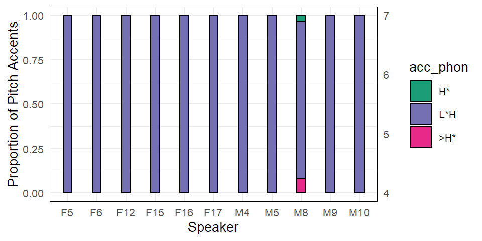

```r
# Percentage Stacked bar

ggplot(
  pa_by_speaker_adj %>%
    #uncount data for chart
    gather("acc_phon", "count", -c(speaker)) %>%
    uncount(count) %>%
    mutate(acc_phon = factor(acc_phon, levels = unique(acc_phon))),
  aes(fill = acc_phon, x = speaker)
) +

  geom_bar(
    stat = "count",
    position = "fill",
    width = 0.30,
    colour = "black"
  ) +

  scale_fill_manual(
    values = pitch_accent_colours[
      colnames(pa_by_speaker_adj[2:length(pa_by_speaker_adj)])
      ]
    ) +


  labs(y = "Proportion of Pitch Accents", x = "Speaker") +
  theme(panel.border = element_rect(fill = NA)) +
  scale_y_continuous(sec.axis = sec_axis(~ . * 3 + 4))
```

#### By Sentence Mode

```r
# Calculate a projected balanced number of tokens for each PA as a function of
# sentence mode.
#
# This takes into consideration the number of utterances per speaker per stimulus and the number of speakers per stimulus.

pa_by_mode_adj %>%
  rename_all(list( ~ str_replace_all(., "([\\*\\[\\^\\>])", "\\\\\\1"))) %>%
  adorn_totals("row") %>%
  formattable(
    caption =
      "Distibution by mode of nuclear pitch accents in M-corpus (adjusted)",
    list(area(col = 2:4, row = 1:4) ~ proportion_bar(color = c(
      rep(brewer.pal(6, "Pastel2")[1], 4),
      rep(brewer.pal(6, "Pastel2")[3], 4),
      rep(brewer.pal(6, "Pastel2")[4], 4)
      )))
    )
```

Distibution by mode of nuclear pitch accents in M-corpus (adjusted)

| mode | H* | L*H | >H* |
| --- | --- | --- | --- |
| MDC | 2 | 162 | 2 |
| MWH | 0 | 165 | 0 |
| MYN | 0 | 163 | 2 |
| MDQ | 0 | 164 | 1 |
| Total | 2 | 654 | 5 |

It is clear that there is little relationship between the pitch accent and mode when the register tier is discounted. However, looking at the raw data for the phrase-level phonology, it looks like L% boundaries are more commonly associated with questions than declarative.

Therefore, it might be worth looking at the nuclear contour as a whole in this data set.

### Nuclear Pitch Contour

```r
# Create tibble summarising nuclear contours per mode per speaker
nuc_contour_adj <- m_corpus %>%
  # Count the number of nuc_contour by speaker and mode
  group_by(speaker, stim, nuc_contour) %>%
  summarise(nuc_count = n(), .groups = "keep") %>%
  pivot_wider(names_from = nuc_contour,
              values_from = nuc_count,
              values_fill = 0) %>%
  # convert the totals to proportion per stim.
  adorn_totals("col") %>%
  mutate(across(3:6,  ~  (. / Total))) %>%
  select(-Total) %>%
  # Convert stim column to mode.
  rename(mode = stim) %>%
  mutate(mode = substr(mode, 1, 3)) %>%
  # Convert the values to proportion per mode
  pivot_longer(3:last_col(), "nuc_contour") %>%
  group_by(speaker, mode, nuc_contour) %>%
  pivot_wider(
    names_from = nuc_contour,
    values_from = value,
    values_fill = 0,
    values_fn = ~ sum(.)
  ) %>%
  adorn_totals("col") %>%
  mutate(across(3:6, ~ (. / Total)),
         mode = factor(mode, levels = c("MDC", "MWH", "MYN", "MDQ"))) %>%
  select(-Total) %>%
  as_tibble()

# Create tibble of nuclear contours per speaker (adjusted).
nuc_contour_by_speaker_adj <- nuc_contour_adj %>%
  # Get the sum of all token proportions per speaker.
  pivot_longer(3:last_col(), "nuc_contour") %>%
  select(-c(mode)) %>%
  pivot_wider(names_from = nuc_contour,
              values_from = value,
              values_fill = 0,
              values_fn = ~ sum(.)
              ) %>%
  # Convert proportions to an integer based on an ideal total number of tokens
  # per speaker.
  mutate(across(2:5, ~ round(. * 15, 0)))

# Create tibble of nuclear contours per mode (adjusted).
nuc_contour_by_mode_adj <- nuc_contour_adj %>%
  # Get the sum of all token proportions per speaker.
  pivot_longer(3:last_col(), "nuc_contour") %>%
  select(-c(speaker)) %>%
  pivot_wider(names_from = nuc_contour,
              values_from = value,
              values_fill = 0,
              values_fn = ~ sum(.)
              ) %>%
  # Convert proportions to an integer based on an ideal total number of tokens.
  mutate(across(2:5, ~ round(. * 15, 0))) %>%
  arrange(mode)

# Create tibble of nuclear contours by gender and mode (adjusted).
nuc_contour_by_gender_adj <- nuc_contour_adj %>%
  # Convert gender to speaker
  mutate(speaker = substr(speaker, 1, 1),
         speaker = factor(speaker, levels=unique(speaker))) %>%
  rename(gender = speaker) %>%
  # Get the sum of all token proportions per speaker.
  pivot_longer(3:last_col(), "nuc_contour") %>%

  pivot_wider(names_from = nuc_contour,
              values_from = value,
              values_fill = 0,
              values_fn = ~ sum(.)
              ) %>%
  # Convert proportions to an integer based on an ideal total number of tokens
  # per speaker.
  mutate(across(3:6, ~ if_else(gender=="F",
                               round(. * 15, 0),
                               # project equal number of Male & Female speakers.
                               round(. * 18, 0)
                               )
                )
         ) %>%
  arrange(mode)
```

#### By speaker and sentence mode (table)

```r
nuc_contour_by_speaker_adj %>%
  rename_all(list(~str_replace_all(., "([\\*\\[\\^\\>])", "\\\\\\1"))) %>%
  adorn_totals(where = "row") %>%
  formattable(
    caption="Distibution by speaker of nuclear contours in M-corpus (adjusted)",
    align="r",
    list(area(col = 2:7, row=1:nrow(.)-1) ~ proportion_bar(color = c(
      rep(brewer.pal(8, "Pastel2")[3], nrow(.)-1),
      rep(brewer.pal(8, "Pastel2")[7], nrow(.)-1),
      rep(brewer.pal(8, "Pastel2")[2], nrow(.)-1),
      rep(brewer.pal(8, "Pastel2")[8], nrow(.)-1),
      rep(brewer.pal(8, "Pastel2")[4], nrow(.)-1),
      rep(brewer.pal(8, "Pastel2")[1], nrow(.)-1)
      )))
    )
```

Distibution by speaker of nuclear contours in M-corpus (adjusted)

| speaker | L*H % | L*H L% | L*H H% | L*H HL% | >H* L% | H* L% |
| --- | --- | --- | --- | --- | --- | --- |
| F5 | 32 | 15 | 7 | 6 | 0 | 0 |
| F6 | 53 | 2 | 3 | 2 | 0 | 0 |
| F12 | 21 | 38 | 1 | 0 | 0 | 0 |
| F15 | 53 | 3 | 4 | 0 | 0 | 0 |
| F16 | 59 | 0 | 1 | 0 | 0 | 0 |
| F17 | 54 | 5 | 1 | 0 | 0 | 0 |
| M4 | 55 | 0 | 5 | 0 | 0 | 0 |
| M5 | 60 | 0 | 0 | 0 | 0 | 0 |
| M8 | 27 | 13 | 0 | 0 | 5 | 2 |
| M9 | 36 | 24 | 0 | 0 | 0 | 0 |
| M10 | 44 | 16 | 0 | 0 | 0 | 0 |
| Total | 494 | 116 | 22 | 8 | 5 | 2 |

#### By speaker and sentence mode (bar chart)

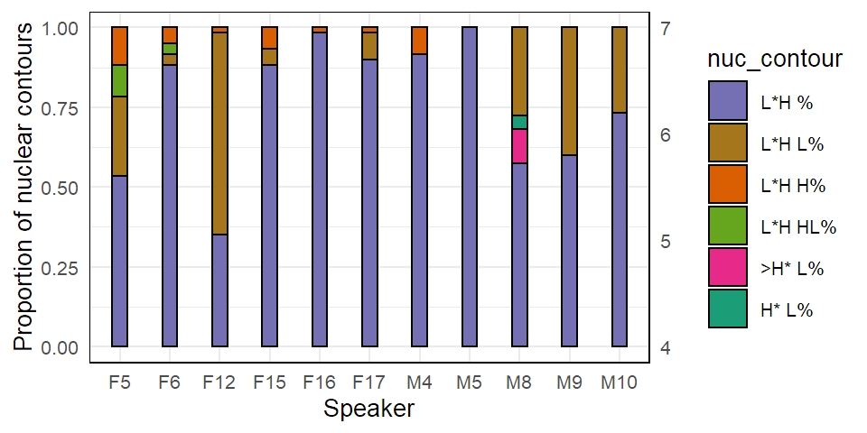

```r
# Percentage Stacked bar
ggplot(data = nuc_contour_by_speaker_adj %>%
         # Uncount table for bar chart
         gather("nuc_contour", "count", -c(speaker)) %>%
         uncount(count) %>%
         #arrange levels
         mutate(nuc_contour = factor(
           nuc_contour,
           levels =
             c("L*H H%", "L*H HL%", "L*H L%", "H* L%",  ">H* L%", "L*H %"))),
       aes(fill = nuc_contour, x = speaker)) +
  geom_bar(stat = "count",
           position = "fill",
           width = 0.30,
           colour = "black") +
  scale_fill_manual(values = nuc_contour_colours
                    [colnames(
                      nuc_contour_by_speaker_adj[2:length(
                        nuc_contour_by_speaker_adj
                        )]
                          )]
                    ) +
  labs(y = "Proportion of nuclear contours",
       x = "Speaker") +
  theme(panel.border = element_rect(fill = NA)) +
  scale_y_continuous(sec.axis = sec_axis(~ . * 3 + 4))
```

#### By nuclear pitch contour and sentence mode

```r
# Calculate a projected balanced number of tokens for each PA as a function of
# sentence mode.
#
# This takes into consideration the number of utterances per speaker per
# stimulus and the number of speakers per stimulus.

nuc_contour_by_mode_adj %>%
  rename_all(list( ~ str_replace_all(., "([\\*\\[\\^\\>])", "\\\\\\1"))) %>%
  adorn_totals("row") %>%
  formattable(caption =
                "Distibution by mode of nuclear contours in M-corpus (adjusted)",
    list(area(col = 2:7, row=1:nrow(.)-1) ~ proportion_bar(color = c(
      rep(brewer.pal(8, "Pastel2")[3], nrow(.)-1),
      rep(brewer.pal(8, "Pastel2")[7], nrow(.)-1),
      rep(brewer.pal(8, "Pastel2")[2], nrow(.)-1),
      rep(brewer.pal(8, "Pastel2")[8], nrow(.)-1),
      rep(brewer.pal(8, "Pastel2")[4], nrow(.)-1),
      rep(brewer.pal(8, "Pastel2")[1], nrow(.)-1)
      )))
  )
```

Distibution by mode of nuclear contours in M-corpus (adjusted)

| mode | L*H % | L*H L% | L*H H% | L*H HL% | >H* L% | H* L% |
| --- | --- | --- | --- | --- | --- | --- |
| MDC | 139 | 17 | 0 | 0 | 2 | 2 |
| MWH | 148 | 17 | 0 | 0 | 0 | 0 |
| MYN | 124 | 29 | 5 | 0 | 2 | 0 |
| MDQ | 82 | 54 | 17 | 8 | 1 | 0 |
| Total | 493 | 117 | 22 | 8 | 5 | 2 |

### Contour by Mode and Gender

It appears that the male speakers are more likely to begin using L% across the question mode hierarchy more than the female speakers. There are not enough speakers, I believe, however, to justify this as a general conclusion, especially as it is only M8, M9, and M10 who do this.

#### Common contours

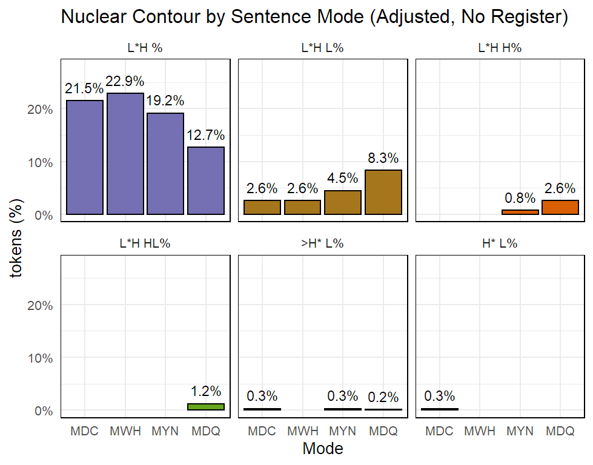

```r
my_plot <- ggplot(
  nuc_contour_by_mode_adj %>%
    # Uncount table for bar chart.
    pivot_longer(2:last_col(), "nuc_contour") %>%
    uncount(value) %>%
    mutate(nuc_contour =
             factor(
               nuc_contour,
               levels = c(
                 "L*H %", "L*H L%", "L*H H%", "L*H HL%", ">H* L%", "H* L%"
                 )
             ))
) +
  geom_bar(
    mapping = aes(
      x = mode,
      y = (..count..) / sum(..count..),
      fill = nuc_contour
    ),
    show.legend = F,
    colour = "black",
    position = position_dodge2(preserve = "single")
  ) +
  scale_y_continuous(labels = scales::percent, limits = c(0, 0.28)) +
  facet_wrap( ~ nuc_contour, nrow = 2) +
  theme(panel.border = element_rect(fill = NA)) +
  ggtitle("Nuclear Contour by Sentence Mode (Adjusted, No Register)") +
  scale_fill_manual(values = nuc_contour_colours, name = "nuclear contour") +
  labs(x = "Mode", y = "tokens (%)") +
  theme(panel.border = element_rect(fill = NA)) +
  geom_text(
    aes(
      x = mode,
      y = (..count..) / sum(..count..),
      label = percent((..count..) / sum(..count..), 1)
    ),
    stat = "count",
    vjust = -0.75,
    size = 3
  )
ggsave(
  filename =
    "output/nuc_contour_by_mode.png",
  plot = my_plot,
  width = 12.95,
  height = 10.16,
  units = "cm",
  dpi = 300
)

my_plot
```

#### All contours

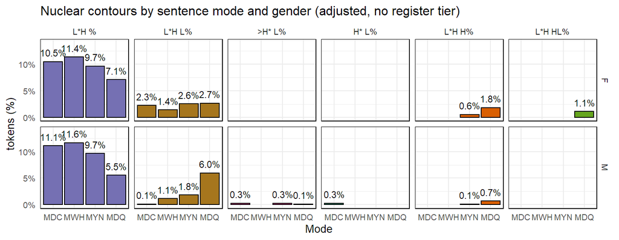

```r
my_plot <- ggplot(
  nuc_contour_by_gender_adj %>%
    # uncount date for chart
    pivot_longer(3:last_col(), "nuc_contour") %>%
    uncount(value) %>%
    mutate(nuc_contour = factor(nuc_contour, levels = unique(nuc_contour))) # %>%
    #filter(nuc_contour %notin% c(">H* L%", "H* L%"))
  ) +
  geom_bar(mapping = aes(x = mode,
                         y = (..count..) / sum(..count..),
                         fill = nuc_contour),
           show.legend = F,
           colour = "black",
           position = position_dodge2(preserve = "single")) +
  scale_y_continuous(labels = scales::percent, limits = c(0, 0.14)) +
  facet_grid(rows = vars(gender), cols = vars(nuc_contour)) +
  theme(
    panel.border = element_rect(fill = NA)
  ) +
  ggtitle(
    "Nuclear contours by sentence mode and gender (adjusted, no register tier)"
    ) +
  scale_fill_manual(values = nuc_contour_colours, name = "nuclear contour") +
  labs(x = "Mode", y = "tokens (%)") +
  theme(panel.border = element_rect(fill = NA)) +
  geom_text(aes(
    x = mode,
    y = (..count..) / sum(..count..),
    label = percent((..count..) / sum(..count..), 1)
  ),
  stat = "count",
  vjust = -0.75,
  size=3)

ggsave(
  filename =
    "output/nuc_contour_by_mode_gender_non_reg.png",
  plot = my_plot,
  width = 22,
  height = 8,
  units = "cm",
  dpi = 300
)
my_plot
```

The overall pattern suggest that L% is more common among YNQs and and DCQs. However, I don’t think that the L% is used to signal a question. I think that, as with the A&H corpus, L% is used when the speaker indicates there is a conflict of expectation of shared knowledge between the speaker and listener. Thus in questions like “You live in the valley?” and “Do you live in the valley?”, speaker can use the L% to indicate that the propositional content conflicts with what he or she had previously believed; i.e., it indicates surprise. In a reciprocal manner, in the declaratives of the A&H corpus (and here), the use of an L% indicates that the speaker is indicating surprise that the listener does not already share the knowledge. (i.e. “Where do you live?…”I live in the valley [L%] (and I assumed you already knew that / and you should know that already.”) … Perhaps the best way to think of this is as the surprise~redundancy strategy, with the conflict of expectations expressing redundancy in the declaratives (“This should not be news to you.”) and surprise in the questions (“I did not know this at all!”).

### Boundary Tone Analysis

```r
fin_phon_adj <- m_corpus %>%
  # Count the number of fin_phon by speaker and mode
  group_by(speaker, stim, fin_phon) %>%
  summarise(nuc_count = n(), .groups = "keep") %>%
  pivot_wider(names_from = fin_phon,
              values_from = nuc_count,
              values_fill = 0) %>%
  # convert the totals to proportion per stim.
  adorn_totals("col") %>%
  mutate(across(3:6,  ~  (. / Total))) %>%
  select(-Total) %>%
  # Convert stim column to mode.
  rename(mode = stim) %>%
  mutate(mode = substr(mode, 1, 3)) %>%
  # Convert the values to proportion per mode
  pivot_longer(3:last_col(), "fin_phon") %>%
  group_by(speaker, mode, fin_phon) %>%
  pivot_wider(
    names_from = fin_phon,
    values_from = value,
    values_fill = 0,
    values_fn = ~ sum(.)
  ) %>%
  adorn_totals("col") %>%
  mutate(across(3:6, ~ (. / Total)),
         mode = factor(mode, levels = c("MDC", "MWH", "MYN", "MDQ"))) %>%
  select(-Total) %>%
  as_tibble()

# Create tibble of final boundaries per mode (adjusted).
fin_phon_by_mode_adj <- fin_phon_adj %>%
  # Get the sum of all token proportions per speaker.
  pivot_longer(3:last_col(), "fin_phon") %>%
  select(-c(speaker)) %>%
  pivot_wider(names_from = fin_phon,
              values_from = value,
              values_fill = 0,
              values_fn = ~ sum(.)
              ) %>%
  # Convert proportions to an integer based on an ideal total number of tokens.
  mutate(across(2:5, ~ round(. * 15, 0))) %>%
  arrange(mode)

# Create tibble of final boundaries  by gender and mode (adjusted).
fin_phon_by_gender_adj <- fin_phon_adj %>%
  # Convert gender to speaker
  mutate(speaker = substr(speaker, 1, 1),
         speaker = factor(speaker, levels=unique(speaker))) %>%
  rename(gender = speaker) %>%
  # Get the sum of all token proportions per speaker.
  pivot_longer(3:last_col(), "fin_phon") %>%

  pivot_wider(names_from = fin_phon,
              values_from = value,
              values_fill = 0,
              values_fn = ~ sum(.)
              ) %>%
  # Convert proportions to an integer based on an ideal total number of tokens
  # per speaker.
  mutate(across(3:6, ~ if_else(gender=="F",
                               round(. * 15, 0),
                               # project equal number of Male & Female speakers.
                               round(. * 18, 0)
                               )
                )
         ) %>%
  arrange(mode)

# Make lists of projected boundary tokens.
fin_phon_by_mode_adj_list <- fin_phon_by_mode_adj %>%
  pivot_longer(2:last_col(), "fin_phon") %>%
    uncount(value) %>%
    mutate(fin_phon = factor(fin_phon, levels = unique(fin_phon)))


# Get list of projected boundary tokens by mode and gender.
fin_phon_by_gender_adj_list <- fin_phon_by_gender_adj %>%
    pivot_longer(3:last_col(), "fin_phon") %>%
    uncount(value) %>%
    mutate(fin_phon = factor(fin_phon, levels = unique(fin_phon)))
```

#### by sentence mode

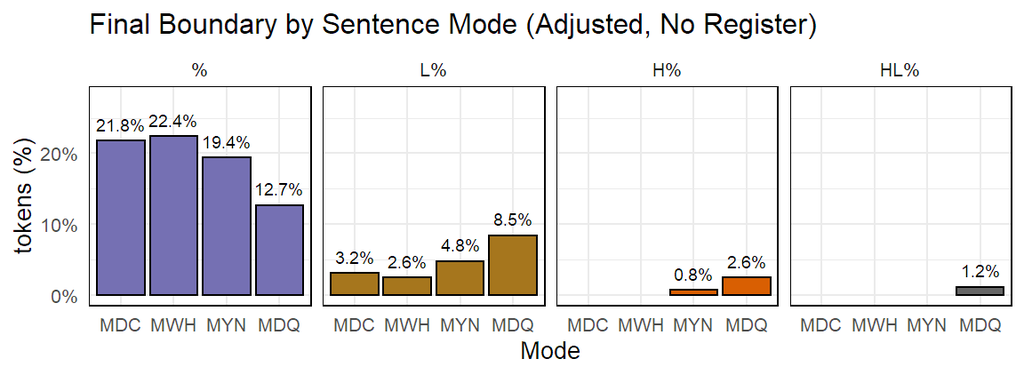

```r
my_plot <- ggplot(fin_phon_by_mode_adj_list) +
  geom_bar(
    mapping = aes(
      x = mode,
      y = (..count..) / sum(..count..),
      fill = fin_phon
    ),
    show.legend = F,
    colour = "black",
    position = position_dodge2(preserve = "single")
  ) +
  scale_y_continuous(labels = scales::percent, limits = c(0, 0.28)) +
  facet_grid(cols = vars(fin_phon)) +
  theme(
    panel.border = element_rect(fill = NA)
  ) +
  ggtitle("Final Boundary by Sentence Mode (Adjusted, No Register)") +
  scale_fill_manual(values = fin_phon_colours, name = "final boundary") +
  labs(x = "Mode", y = "tokens (%)") +
  theme(panel.border = element_rect(fill = NA)) +
  geom_text(aes(
    x = mode,
    y = (..count..) / sum(..count..),
    label = percent((..count..) / sum(..count..), 1)
  ),
  stat = "count",
  vjust = -0.75,
  size = 2.5)


ggsave(
  filename =
    "output/fin_phon_by_mode_non_reg.png",
  plot = my_plot,
  width = 15.5,
  height = 5.5,
  units = "cm",
  dpi = 300
)

my_plot
```

#### by sentence mode and gender

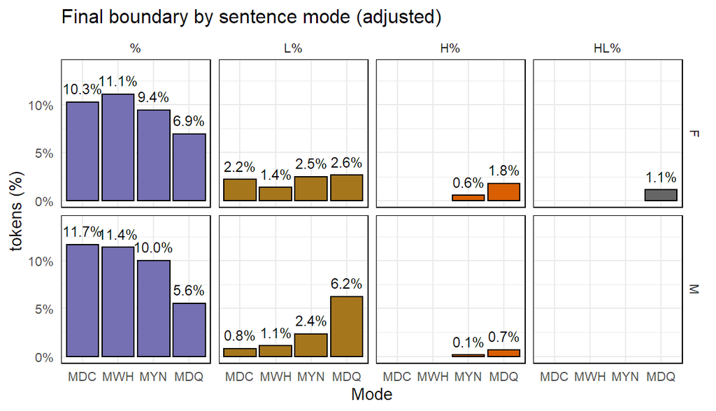

```r
my_plot <- ggplot(fin_phon_by_gender_adj_list) +
  geom_bar(
    mapping = aes(
      x = mode,
      y = (..count..) / sum(..count..),
      fill = fin_phon
    ),
    show.legend = F,
    colour = "black",
    position = position_dodge2(preserve = "single")
  ) +
  scale_y_continuous(labels = scales::percent, limits = c(0, 0.14)) +
  facet_grid(rows = vars(gender), cols = vars(fin_phon)) +
  ggtitle(
    "Final Boundary by Sentence Mode and Gender (Adjusted, No Register)"
    ) +
  theme(
    panel.border = element_rect(fill = NA)
  ) +
  ggtitle("Final boundary by sentence mode (adjusted)") +
  scale_fill_manual(values = fin_phon_colours, name = "nuclear contour") +
  labs(x = "Mode", y = "tokens (%)") +
  theme(panel.border = element_rect(fill = NA)) +
  geom_text(aes(
    x = mode,
    y = (..count..) / sum(..count..),
    label = percent((..count..) / sum(..count..), 1)
  ),
  stat = "count",
  vjust = -0.75,
  size = 3)

ggsave(
  filename =
    "output/fin_phon_by_mode_gender_non_reg.png",
  width = 15.5,
  plot = my_plot,
  height = 8.5,
  units = "cm",
  dpi = 300
)

my_plot
```

The results give the impression that this is a feature of male rather than female speech. However, only three out of the five male speakers do this, so it is unlikely to be a features of “male speech”. More likely, different speakers interpreted the motivation behind the prompt statement and their response, in terms of the intonational phonology, reflects whether or not they chose to use a surprise/redundancy falling boundary.

## BGLMM analysis

### Likelihood of H%.

**Complete separation issue**

- GLMER cannot correctly estimate the CIs of H:L for MDC and MWH since there are no instances of H for either level, leading to a problem know as “complete separation”.

To resolve this issue, I have used the blme package, which uses “Maximum a posteriori estimation for linear and generalized linear mixed-effects models in a Bayesian setting” (documentation).

We can use this to “impose zero-mean Normal priors on the fixed effects (a 4 × 4 diagonal matrix with diagonal elements equal to 9, for variances of 9 or standard deviations of 3)”

(http://bbolker.github.io/mixedmodels-misc/ecostats_chap.html#digression-complete-separation)

(directed from https://bbolker.github.io/mixedmodels-misc/glmmFAQ.html#penalizationhandling-complete-separation)

```r
m_corpus_is_H_boundary <- m_corpus %>%
  # treat HL% as for purpose of % vs H%
  mutate(`H%` =  str_replace(fin_phon, "HL\\%", "H%")) %>%
  mutate(`H%` = factor(`H%` == "H%", level = c(F, T)))
```

```r
fin_phon_model_H_or_not <- bglmer(
  `H%` ~ mode + gender + (1 | speaker) + (1 | prompt),
  data = m_corpus_is_H_boundary,
  family = binomial(link = "logit"),
  fixef.prior = normal(),
  # change optimizer to avoid convergence errors
  control = glmerControl(
    optimizer = "optimx",
    calc.derivs = FALSE,
    optCtrl = list(
      method = "nlminb",
      starttests = FALSE,
      kkt = FALSE
    )
  )
)

fin_phon_model_H_or_not <- optimizeModel(fin_phon_model_H_or_not, reject_nm = F)
```

#### LRT via drop1()

```r
write = "output/Mode_fin_phon_no_Reg_0H"

model_formula <- getModelFormula(fin_phon_model_H_or_not)

write(paste(str_replace_all(model_formula, "\\`", ""), sep = ""),
      paste(write, "_formula.txt", sep = ""))


# get, save, and print ANOVA of model
drop1_analysis <- drop1(fin_phon_model_H_or_not, test = "Chisq")

tibble(factor = row.names(drop1_analysis))  %>%
  cbind(tibble(drop1_analysis)) %>%
  filter(!is.na(npar)) %>%
  mutate(`p.adj (BH)` = NA, signif. = NA) %>%
  write_csv(paste0(write, "_anova.csv"))


adjustP_posthoc("output/",
                `Pr(Chi)`,
                suffix_id = "_anova")

read_csv(paste(write, "_anova.csv", sep = "")) %>%
  tidyStatNumbers() %>%
formattable(caption = paste("Drop 1 ChiSq test of model:", model_formula))
```

Drop 1 ChiSq test of model: `H%` ~ mode + gender + (1 | speaker) + (1 | prompt)

| factor | npar | AIC | LRT | Pr(Chi) | p.adj (BH) | signif. |
| --- | --- | --- | --- | --- | --- | --- |
| mode | 3 | 223.2 | 65.02 | < .001 | < .001 | *p* < .05 |
| gender | 1 | 165.64 | 3.45 | .063 | .076 |  |

#### *R*<sup>2</sup> and prediction plots

Conditional and marginal R<sup>2</sup> of model

| marginal R<sup>2</sup> | conditional R<sup>2</sup> |
| --- | --- |
| .41 | .75 |

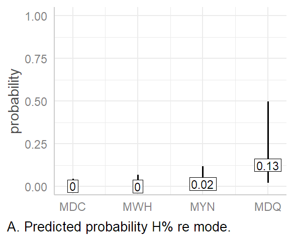

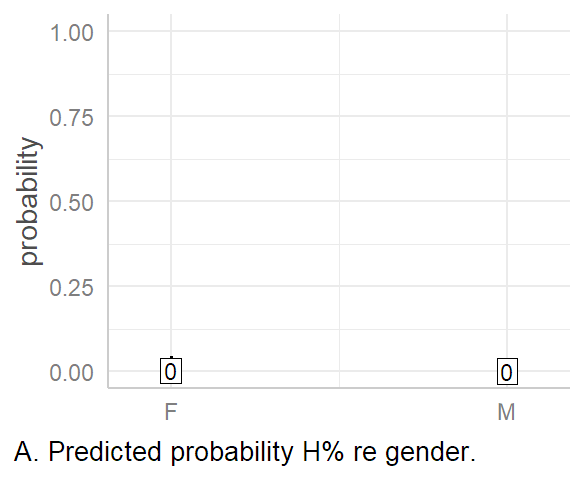

```r
tidy_summary <- analyseModel(
  fin_phon_model_H_or_not,
  write = write,
  is_GLM = T,
  type = "pred",
  plot_rounding = 2,
  short_caption = F,
  panel_prefix = "A. "
)
```

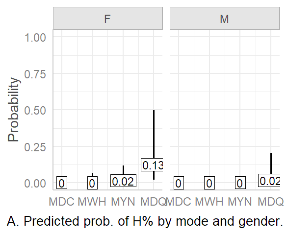

```r
my_plot <-
  ggpredict(fin_phon_model_H_or_not,
            terms = c("mode", "gender"),
            ci.lvl = 0.95) %>%
  plot(grid = T, colors = "bw") +
  labs(caption = "A. Predicted prob. of H% by mode and gender.") +
  geom_label(
    aes(label = round(predicted, 2)),
    label.padding = unit(0.5, "mm"),
    label.r = unit(0.0, "mm"),
    size = 3
  ) +
  scale_y_continuous(limits = c(0, 1)) +
  ylab("Probability") +
  theme(
    plot.title = element_blank(),
    axis.title.x = element_blank(),
    plot.caption = element_text(hjust = 0, size = 10),
    plot.caption.position = "plot",
    legend.position = c(0.12, 0.8),
    legend.background = element_rect(colour = "darkGray")
  )

ggsave(
  filename =
    paste0(write, "_multi_pred.png"),
  plot = my_plot,
  # width = 8.14,
  width = 14,
  height = 6.26,
  units = "cm",
  dpi = 300
)

print(my_plot)
```

#### Prediction tables

```r
printTidyPredictions(fin_phon_model_H_or_not,
                     caption_suffix = " (no reg tier)",
                     digits = 3)
```

Predicted probabilities of H% (no reg tier)

| mode | predicted | conf.low | conf.high | std.error |
| --- | --- | --- | --- | --- |
| MDC | 0.002 | < 0.001 | 0.043 | 1.526 |
| MWH | < 0.001 | < 0.001 | 0.069 | 2.47 |
| MYN | 0.015 | 0.002 | 0.117 | 1.092 |
| MDQ | 0.125 | 0.02 | 0.496 | 0.984 |

Predicted probabilities of H% (no reg tier)

| gender | predicted | conf.low | conf.high | std.error |
| --- | --- | --- | --- | --- |
| F | 0.002 | < 0.001 | 0.043 | 1.526 |
| M | < 0.001 | < 0.001 | 0.01 | 1.782 |

#### Pairwise comparisons

```r
charts <- getModelFixedFX(
  fin_phon_model_H_or_not,
  write = write,
  exponentiate = T
)
#charts$intercepts
charts$slopes %>% tidyStatNumbers()
```

b1 for H% ~ mode + gender + (1 | speaker) + (1 | prompt)

[output not shown]

#### Model printout

```r
summary(fin_phon_model_H_or_not)
```

```
## Cov prior  : speaker ~ wishart(df = 3.5, scale = Inf, posterior.scale = cov, common.scale = TRUE)
##            : prompt ~ wishart(df = 3.5, scale = Inf, posterior.scale = cov, common.scale = TRUE)
## Fixef prior: normal(sd = c(10, 2.5, ...), corr = c(0 ...), common.scale = FALSE)
## Prior dev  : 24.292
##
## Generalized linear mixed model fit by maximum likelihood (Laplace
##   Approximation) [bglmerMod]
##  Family: binomial  ( logit )
## Formula: `H%` ~ mode + gender + (1 | speaker) + (1 | prompt)
##    Data: m_corpus_is_H_boundary
## Control:
## glmerControl(optimizer = "optimx", calc.derivs = FALSE, optCtrl = list(method = "nlminb",
##     starttests = FALSE, kkt = FALSE))
##
##      AIC      BIC   logLik deviance df.resid
##    164.2    195.4    -75.1    150.2      632
##
## Scaled residuals:
##     Min      1Q  Median      3Q     Max
## -1.4111 -0.1227 -0.0412 -0.0180  4.7220
##
## Random effects:
##  Groups  Name        Variance Std.Dev.
##  speaker (Intercept) 3.7152   1.9275
##  prompt  (Intercept) 0.7351   0.8574
## Number of obs: 639, groups:  speaker, 11; prompt, 3
##
## Fixed effects:
##             Estimate Std. Error z value Pr(>|z|)
## (Intercept)   -6.093      1.526  -3.993 6.52e-05 ***
## modeMWH       -1.349      2.552  -0.529 0.596977
## modeMYN        1.929      1.276   1.511 0.130706
## modeMDQ        4.148      1.213   3.420 0.000626 ***
## genderM       -2.037      1.497  -1.360 0.173819
## ---
## Signif. codes:  0 '***' 0.001 '**' 0.01 '*' 0.05 '.' 0.1 ' ' 1
##
## Correlation of Fixed Effects:
##         (Intr) modMWH modMYN modMDQ
## modeMWH -0.352
## modeMYN -0.710  0.421
## modeMDQ -0.765  0.443  0.891
## genderM -0.305  0.000 -0.003 -0.008
```

```r
cat("isSingular(fin_phon_model_H_or_not, tol=1e-5) -->",
    isSingular(fin_phon_model_H_or_not, tol = 1e-5),
    "\n")
```

```
## isSingular(fin_phon_model_H_or_not, tol=1e-5) --> FALSE
```